# Das_et_al_2020

### Set working directory

```r
setwd("/Users/sdas/16S_data/all_run_240219/merged_060319")
```

### Load packages

```r
library(ggplot2)
library(rmarkdown)
library(vegan) # ecological diversity analysis
library(dplyr)
library(scales) # scale functions for vizualizations
library(grid)
library(reshape2) # data manipulation package
library(ape)
library(devtools)
library(biomformat)
library(phyloseq)
library(ampvis2)
library(plotly)
library(genefilter)
library(Rtsne)
library(microbiome)
library(BiocInstaller)
library(metacoder)
library(taxa)
library(edgeR)
library(grid)
library(plyr)
library(genefilter)
library(metagenomeSeq)
library(fso)
library(philentropy)
library(gplots)
library(DESeq2)
library(ampvis2)
library(RColorBrewer)
library(ComplexHeatmap)
library(pheatmap)
library(superheat)
library(car)
library(intergraph)
library(GGally)
library(network)
library(ggnet)
library(ggnetwork)
library(divo)
library(extrafont)
library(apeglm)
library(EnhancedVolcano)
library(gridExtra)
library(grid)
library(IHW)
library(gtx)
library(PMCMR)
library(ggpubr)
library(EnvStats)
library(randomForestExplainer)
library(randomForest)
library(markovchain)
library(tidyverse)
library(forcats)
library(ARTool)
library(emmeans)
library(multcomp)
library(phia)
library(markovchain)
library(randomForest)
library(dplyr) # for the "arrange" function
library(rfUtilities) # to test model significance
```

### Functions

```r
#Summary SE function
summarySE <- function(data=NULL, measurevar, groupvars=NULL, na.rm=FALSE,
                      conf.interval=.95, .drop=TRUE) {
  library(plyr)


  length2 <- function (x, na.rm=FALSE) {
    if (na.rm) sum(!is.na(x))
    else       length(x)
  }
  datac <- ddply(data, groupvars, .drop=.drop,
                 .fun = function(xx, col) {
                   c(N    = length2(xx[[col]], na.rm=na.rm),
                     mean = mean   (xx[[col]], na.rm=na.rm),
                     sd   = sd     (xx[[col]], na.rm=na.rm)
                   )
                 },
                 measurevar
  )
  datac <- rename(datac, c("mean" = measurevar))

  datac$se <- datac$sd / sqrt(datac$N)

  ciMult <- qt(conf.interval/2 + .5, datac$N-1)
  datac$ci <- datac$se * ciMult

  return(datac)
}
```

### Set plotting theme and font

```r
theme_set(theme_bw())
choose_font("Arial")
```

### Creating a phyloseq object

```r
ltx_otus
```

```
phyloseq-class experiment-level object
otu_table()   OTU Table:         [ 8178 taxa and 275 samples ]
sample_data() Sample Data:       [ 275 samples by 50 sample variables ]
tax_table()   Taxonomy Table:    [ 8178 taxa by 7 taxonomic ranks ]
phy_tree()    Phylogenetic Tree: [ 8178 tips and 8170 internal nodes ]
```

##renaming taxonomy column names

```r
colnames(tax_table(ltx_otus)) <- c("Kingdom", "Phylum", "Class", "Order", "Family", "Genus","Species")
rank_names(ltx_otus)
```

##Create table, number of features for each phyla

```r
table(tax_table(ltx_otus)[, "Phylum"], exclude = NULL)
```

##Exploring metadata

```r
sample_names(ltx_otus)
```

#Save workspace

```r
save.image(file = "FILE.RData")
load(file = "FILE.RData")
```

###Storing Lumicol in another object for further exploration

```r
lumicol<-subset_samples(ltx_otus,Sample_SD=="LUMICOL")
lumicol
```

#Data exploration ###Quality control of data

```r
readsumsdf = data.frame(nreads = sort(taxa_sums(ltx_otus), TRUE), sorted = 1:ntaxa(ltx_otus), type = "OTUs")
readsumsdf = rbind(readsumsdf, data.frame(nreads = sort(sample_sums(ltx_otus),TRUE), sorted = 1:nsamples(ltx_otus), type = "Samples"))
title = "Total number of reads"
p = ggplot(readsumsdf, aes(x = sorted, y = nreads)) + geom_point()
p + ggtitle(title) + scale_y_log10() + facet_wrap(~type, 1, scales = "free")
```

###Converting phyloseq to ampvis2

```r
obj1<-ltx_otus
otutable <- data.frame(OTU = rownames(phyloseq::otu_table(obj1)@.Data),
                       phyloseq::otu_table(obj1)@.Data,
                       phyloseq::tax_table(obj1)@.Data,
                       check.names = FALSE
                       )

meta2<- data.frame(phyloseq::sample_data(obj1), check.names = FALSE)
object1<-amp_load(otutable,meta2,fasta = "c0_otus_final_sorted_phifil_test.fa ")

#alternative when direct import fails
meta2<-read.table("metadata.txt",header = T)
object1<- amp_load(otutable,meta2,fasta = "c0_otus_final_sorted_phifil_test.fa ")
```

###Analysis of negative control

```r
negatives<- amp_subset_samples(object1, NegCtrl %in% "1")
negative_otus<-cbind(negatives$abund,negatives$tax)
write.csv(negative_otus,"negative_control_OTU_table_wTaxa.csv")
```

###boxplots of the most abundant taxa according to read counts.

|  | Display | Sample | Abundance | Group |
| --- | --- | --- | --- | --- |
| 1 | OTU_1; Pseudomonas | BAL284.neg | 1 | BAL284.neg |
| 2 | OTU_1; Pseudomonas | ExtrNC | 1 | ExtrNC |
| 3 | OTU_1; Pseudomonas | NC.PCR.1 | 1 | NC.PCR.1 |
| 4 | OTU_1; Pseudomonas | NC.PCR.2 | 1 | NC.PCR.2 |
| 5 | OTU_1; Pseudomonas | NC.PCR.3 | 1 | NC.PCR.3 |
| 6 | OTU_1; Pseudomonas | NC.PCR.4 | 1 | NC.PCR.4 |
| 7 | OTU_1; Pseudomonas | Neg.ctrl.1 | 11 | Neg.ctrl.1 |
| 8 | OTU_1; Pseudomonas | Neg.ctrl.2 | 9 | Neg.ctrl.2 |
| 9 | OTU_1; Pseudomonas | Neg.ctrl.3 | 3 | Neg.ctrl.3 |
| 10 | OTU_1; Pseudomonas | Neg.ctrl.4 | 2 | Neg.ctrl.4 |

[output cut: 320 more lines]

```
NA
```

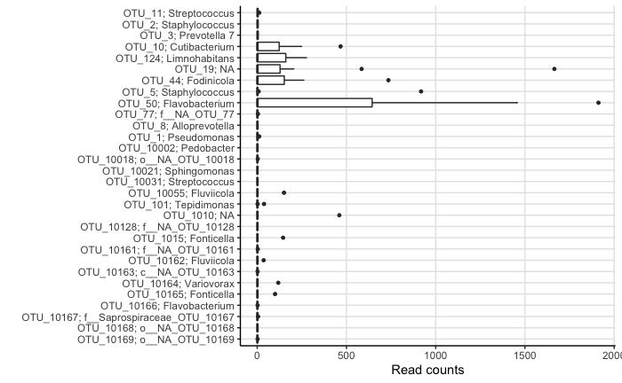

```r
neg_ctrl
```

###boxplots of the most abundant taxa according to read counts and grouped by samples

```r
neg_sample<-amp_boxplot(negatives,adjust_zero=T,tax_add="OTU",plot_type = "point",detailed_output=TRUE,normalise = F,group_by = "Sample_SD")
neg_sample$plot
write.table(neg_sample$data,file = "negative_non_normalized_by_sample.txt")
```

###heatmap of the most abundant taxa according to read counts and grouped by samples

```r
neg_heat<-amp_heatmap(negatives,normalise = F,tax_add="OTU",tax_aggregate = "Genus",tax_show = 40,plot_values =F,color_vector = c("white","red","darkred"),min_abundance = 0.1,measure = "median")
```

###Removing negative controls from phyloseq object.

```r
ltx_noneg<-subset_samples(ltx_otus,NegCtrl!=1)
ltx_noneg
```

###Take out samples with NA in 16S copy column.

```r
ltx_otus3
```

```
phyloseq-class experiment-level object
otu_table()   OTU Table:         [ 8178 taxa and 256 samples ]
sample_data() Sample Data:       [ 256 samples by 50 sample variables ]
tax_table()   Taxonomy Table:    [ 8178 taxa by 7 taxonomic ranks ]
phy_tree()    Phylogenetic Tree: [ 8178 tips and 8170 internal nodes ]
```

###Removal of contaminating OTUs

```
As we saw before, there are some OTUs that come from the negative controls. We will remove them.
```

```r
ltx_otus5
```

```
phyloseq-class experiment-level object
otu_table()   OTU Table:         [ 8024 taxa and 256 samples ]
sample_data() Sample Data:       [ 256 samples by 50 sample variables ]
tax_table()   Taxonomy Table:    [ 8024 taxa by 7 taxonomic ranks ]
phy_tree()    Phylogenetic Tree: [ 8024 tips and 8016 internal nodes ]
```

[output not shown]

```r
ltx_rare
```

[output not shown]

###Compositional data

```r
ltx_rare_rel
```

```
phyloseq-class experiment-level object
otu_table()   OTU Table:         [ 7164 taxa and 234 samples ]
sample_data() Sample Data:       [ 234 samples by 81 sample variables ]
tax_table()   Taxonomy Table:    [ 7164 taxa by 7 taxonomic ranks ]
phy_tree()    Phylogenetic Tree: [ 7164 tips and 7157 internal nodes ]
```

```r
tax_summary<-table(tax_table(eric.june2019)[, "Phylum"], exclude = NULL)
write.csv(tax_summary,"tables/tax_summary_S1.csv")
```

###Compute prevalence of each feature, store as data.frame

```r
prevdf = apply(X = otu_table(ltx_rare),
               MARGIN = ifelse(taxa_are_rows(ltx_rare), yes = 1, no = 2),
               FUN = function(x){sum(x > 0)})
```

###Add taxonomy and total read counts to this data.frame

```r
prevdf = data.frame(Prevalence = prevdf,TotalAbundance = taxa_sums(ltx_rare),tax_table(ltx_rare))
plyr::ddply(prevdf, "Phylum", function(df1){cbind(mean(df1$Prevalence),sum(df1$Prevalence))})
```

###Subset to the remaining phyla

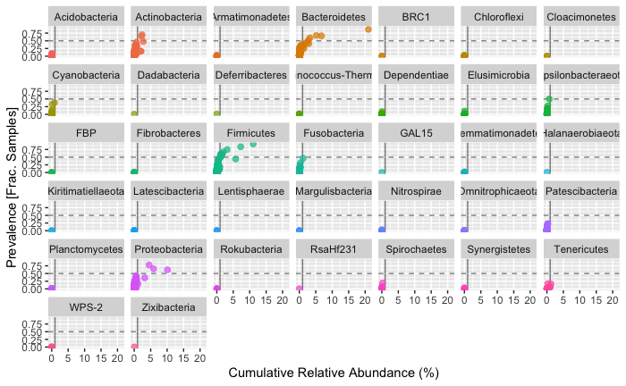

###Define prevalence threshold as 50% of total samples

```r
prevalenceThreshold = 0.5 * nsamples(ltx_rare_rel)
prevalenceThreshold
```

###Execute prevalence filter, using `prune_taxa()` function.

```r
keepTaxa = rownames(prevdf1)[(prevdf1$Prevalence >= prevalenceThreshold)]
hi_prev_rel = prune_taxa(keepTaxa, ltx_rare_rel)
sample_sums(hi_prev_rel)
write.csv(sample_sums_prev,"tables/sample_sums_prev.csv")
prevdf2 = subset(prevdf1, Genus %in% get_taxa_unique(hi_prev_rel, "Genus"))
prev_plot2<-ggplot(prevdf2, aes(TotalAbundance, Prevalence / nsamples(hi_prev_rel),color=Genus,size=TotalAbundance)) +geom_hline(yintercept = 0.5, alpha = 0.5, linetype = 2) + geom_point(alpha = 0.7) +geom_vline(xintercept = 2000,alpha = 0.5, linetype = 1)+ xlab("total rarefied reads") + ylab("Prevalence (fraction of samples)")+ theme(legend.text = element_text(size = 8),legend.position="bottom",axis.text.y= element_text(size = 20),axis.text.x= element_text(angle = 90),strip.text = element_text(size=15))+scale_y_continuous(limits = c(0,1))+facet_grid(~Phylum)
write.csv(prevdf1,"tables/final_tables/new_prevalence_table.csv")
#extracting prevalent taxa from eric new
prev_otus<-as(otu_table(hi_prev_rel),"matrix")
prev_otus<-t(prev_otus)
write.csv(prev_otus,"tables/final_tables/prev_otus.csv")
prev_meta<-as(sample_data(hi_prev_rel),"data.frame")
sample_data(hi_prev_rel)
tax_summary<-table(tax_table(hi_prev_rel)[, "Phylum"], exclude = NULL)
View(tax_summary)
prev_plot2
```

###Converting ltx_rare_rel object to ampvis object

```r
obj3<-ltx_rare_rel
otutable_exp <- data.frame(OTU = rownames(phyloseq::otu_table(obj3)@.Data),
                       phyloseq::otu_table(obj3)@.Data,
                       phyloseq::tax_table(obj3)@.Data,
                       check.names = FALSE
                       )
erc.tree=phy_tree(ltx_rare_rel)
meta_exp<- data.frame(phyloseq::sample_data(obj3), check.names = FALSE)
amp_exp<-amp_load(otutable_exp,meta_exp,tree = erc.tree)
amp_exp
amp_box_phyla<-amp_boxplot(amp_exp,sort_by = "median",adjust_zero = T,detailed_output = T)+theme(axis.text.y = element_text(face="italic",size=12),axis.text.x = element_text(size=20),axis.title = element_text(size = 20))
detailed_taxa<-amp_frequency(amp_exp, tax_aggregate = "Genus",detailed_output = T)
View(detailed_taxa$data)
write.csv(detailed_taxa$data,"tables/amp_freq_detailed_genus.csv")
amp_box_median<-amp_boxplot(amp_exp,sort_by = "median",tax_aggregate = "OTU",tax_add = "Genus",tax_show = 22)+theme(axis.text.y = element_text(face="italic",size=12),axis.text.x = element_text(size=20),axis.title = element_text(size = 18))
amp_box_median
```

#richness vs bacterial copy

```r
alpha_summary<-amp_alphadiv(amp_exp)
alpha_summary$log_copy<-log10(alpha_summary$Cop16SPerMLBAL)
mode(alpha_summary$log_copy)
otu_bact_copy<-ggplot(alpha_summary,aes(log_copy,ObservedOTUs))+geom_point()+geom_smooth(method = "lm",formula = y ~ log(x))+theme(axis.text = element_text(size = 20))+scale_y_continuous(limits = c(0,4))+scale_x_continuous(limits = c(1,7),breaks = c(1,2,3,4,5,6,7))
otu_copy_lm<-(lm(log_copy~ObservedOTUs,data=alpha_summary))
summary(otu_copy_lm)
# Create the function.
getmode <- function(v) {
   uniqv <- unique(v)
   uniqv[which.max(tabulate(match(v, uniqv)))]
}

getmode(alpha_summary$log_copy)
alpha_summary$pielou<-alpha_summary$Shannon/log(alpha_summary$ObservedOTUs)
otu_bact_copy
```

###core analysis using eric’s data at OTU level

```r
amp_exp
core<-amp_core(amp_exp,tax_empty = "OTU",tax_aggregate = "OTU",abund_thrh = 1,detailed_output=T,plotly = T)
write.csv(eric_core$data,"tables/incidence_abundance.csv")
core_data<-read.csv("tables/incidence_abundance.csv")
```

###Creating a simple incidence plot

```r
incidence<-read.csv("tables/incidence_abundance.csv")
incidence$taxa_info<-paste(incidence$Genus,";",incidence$OTU)
incidence$col=ifelse(incidence$Freq_percent>50,paste(incidence$taxa_info),"NA")
incidence_eric
freq_plot<-ggplot(incidence,aes(x=reorder(OTU,-Freq_percent),y=Freq_percent))+geom_point(aes(color=factor(col)),size=3)+theme(legend.position =c(0.3,0.5),legend.text = element_text(size = 10,face="italic"),axis.title= element_blank(),axis.text.x = element_blank(),axis.text = element_text(size = 20),panel.grid=element_blank())+guides(fill=guide_legend(ncol = 3,byrow = T))+ylim(0,100)
freq_plot
```

###Refining the incidence and creating rank abundance plot

```r
clusterData_eric = filter(incidence,Frequency >=23)
View(clusterData)
clusterData$col=ifelse(clusterData$Abundance>1,paste(clusterData$taxa_info),"NA")
rank_eric_otus<-ggplot(clusterData,aes(x=reorder(OTU,-Abundance),y=Abundance))+geom_point(aes(color=factor(col)),size=3)+theme(legend.position =c(0.1,0.5),axis.title= element_blank(),axis.text.x = element_blank(),axis.text = element_text(size = 20),panel.grid=element_blank(),legend.text = element_text(size = 10,face="italic"),panel.border =element_rect(colour="black"))+geom_hline(yintercept = 1, linetype = 2,color="red")
rank_eric_otus
```

#normalized phyloseq object

```r
ltx_rare_rel
ltx.rare.rel.abs <- ltx_rare_rel
for(n in 1:nsamples(ltx_rare_rel))
{
otu_table(ltx.rare.rel.abs)[,n] <- otu_table(ltx_rare_rel)[,n]*sample_data(ltx_rare_rel)$Cop16SPerMLBAL [n]
}
ltx.rare.rel.abs
```

###Extracting lumicol bacteria data

```r
lumicol_otus<-c("OTU_69",
"OTU_30",
"OTU_38",
"OTU_3427",
"OTU_27",
"OTU_219",
"OTU_2",
"OTU_1",
"OTU_3227",
"OTU_592",
"OTU_9786",
"OTU_513",
"OTU_107",
"OTU_1474",
"OTU_263",
"OTU_699",
"OTU_328",
"OTU_501",
"OTU_39",
"OTU_20",
"OTU_34",
"OTU_7",
"OTU_143",
"OTU_5553",
"OTU_11",
"OTU_228",
"OTU_55",
"OTU_41",
"OTU_9424",
"OTU_205",
"OTU_57",
"OTU_67",
"OTU_3",
"OTU_5034",
"OTU_113",
"OTU_115",
"OTU_6",
"OTU_58",
"OTU_1567",
"OTU_7830",
"OTU_42",
"OTU_336",
"OTU_17",
"OTU_161",
"OTU_10031",
"OTU_4021",
"OTU_5247")
lumicol_extraction<-prune_taxa(lumicol_otus,lumicol)
lumicol_tree<-phy_tree(lumicol_extraction)
ape::write.tree(lumicol_tree,file="lumicol_singles.tre")
```

#Extracting the most important contributors - 30 OTUs

```r
imp2<-c("OTU_11",
"OTU_3",
"OTU_6",
"OTU_15",
"OTU_30",
"OTU_20",
"OTU_8",
"OTU_17",
"OTU_4",
"OTU_7",
"OTU_39",
"OTU_1",
"OTU_41",
"OTU_27",
"OTU_34",
"OTU_107",
"OTU_57",
"OTU_26",
"OTU_42",
"OTU_69",
"OTU_21",
"OTU_46",
"OTU_2",
"OTU_16",
"OTU_24",
"OTU_49",
"OTU_78",
"OTU_6768",
"OTU_234",
"OTU_63")
imp2
impTaxa2<-prune_taxa(imp2,ltx.rare.rel.abs)
impTaxa2
#Contribution of 30 taxa on total reads
sum(sample_sums(impTaxa2))/sum(sample_sums(ltx_rare_rel))*100
```

###Converting most important OTUs to ampvis object

```r
imp_obj<-impTaxa
otutable_imp <- data.frame(OTU = rownames(phyloseq::otu_table(imp_obj)@.Data),
                       phyloseq::otu_table(imp_obj)@.Data,
                       phyloseq::tax_table(imp_obj)@.Data,
                       check.names = FALSE
                       )
imp_exp<- data.frame(phyloseq::sample_data(imp_obj),check.names = FALSE)
amp_imp<-amp_load(otutable_imp,imp_exp)
imp_heat<-amp_heatmap(amp_imp,tax_aggregate = "OTU",tax_show = 29,color_vector = c("white","red","darkred"),min_abundance = 1.0,group_by = "kmed_2",textmap = F)
```

###Extracting LuMiCol OTUs

```r
lumicol_otus<-read.table("/Users/sdas/16S_data/all_run_240219/merged_060319/tables/final_tables/lumicol_otus_to_extract.txt",stringsAsFactors = FALSE)
lumicol<-lumicol_otus$V1
lumicol_singles<-prune_taxa(lumicol,ltx_rare_rel)
lumicol_singles
ape::write.tree(phy_tree(lumicol_singles), "phylogeny/lumicol_singles_tree.tre")
```

```
PAM colors
"#de2d26","#41ab5d","#0c2c84","#fe9929"
```

#Subset samples and analysis of according to pams into its phyloseq and ampvis2 objects ###PAM1 as example, applied to all PAMs

```r
pam1<-subset_samples(ltx.rare.rel,kmed_2=="pam1")
pam1.obj<-pam1
pam1.otutable <- data.frame(OTU = rownames(phyloseq::otu_table(pam1.obj)@.Data),
                       phyloseq::otu_table(pam1.obj)@.Data,
                       phyloseq::tax_table(pam1.obj)@.Data,
                       check.names = FALSE
                       )
pam1.tree=phy_tree(pam1)
pam1.meta<- data.frame(phyloseq::sample_data(pam1.obj), check.names = FALSE)
amp_pam1<-amp_load(pam1.otutable,pam1.meta,tree = pam1.tree)
pam1_core<-amp_core(amp_pam1,tax_empty = "OTU",tax_aggregate = "OTU",abund_thrh = 1,detailed_output=T)
write.csv(pam1_core$data,"tables/pam1_incidence_abundance.csv")

pam_freq<-read.csv("tables/final_tables/pam1_core_incidence.csv",header = T)
head(pam_freq)

melted_pam_freq<-melt(pam_freq)

my_levels<-c("OTU_11",
"OTU_3",
 "OTU_6",
 "OTU_15",
 "OTU_30",
 "OTU_20",
 "OTU_8",
 "OTU_17",
 "OTU_4",
 "OTU_7",
 "OTU_39",
 "OTU_1",
 "OTU_41",
 "OTU_27",
 "OTU_34",
 "OTU_107",
 "OTU_57",
 "OTU_26",
 "OTU_42",
 "OTU_69",
 "OTU_21",
 "OTU_46",
 "OTU_2",
 "OTU_24",
 "OTU_78",
 "OTU_16",
 "OTU_49",
 "OTU_234",
 "OTU_63",
 "OTU_6768")

melted_pam_freq$taxa_info<- factor(taxa_info, levels=c("OTU_11","OTU_3","OTU_6","OTU_15","OTU_30","OTU_20","OTU_8","OTU_17",
 "OTU_4","OTU_7","OTU_39","OTU_1","OTU_41","OTU_27","OTU_34","OTU_107","OTU_57","OTU_26","OTU_42",
"OTU_69","OTU_21","OTU_46","OTU_2","OTU_24","OTU_78","OTU_16","OTU_49","OTU_234","OTU_63","OTU_6768"))

my_levels<-pam_freq$taxa_info<- as.factor(as.character(
pam_freq$taxa_info))

pam_core_plot<-ggplot(melted_pam_freq,aes(group=variable,fill=variable,x=taxa_info,y=value))+geom_bar(position="dodge",stat="identity")+geom_hline(yintercept = 50, linetype = 2,color="#006600")+theme(axis.text.x = element_text(size=12,angle = 90,face="italic"),axis.text.y = element_text(size = 15),axis.title = element_blank(),legend.position = "none",panel.grid.major = element_blank(), panel.grid.minor = element_blank(),
panel.background = element_blank())+scale_fill_manual(values=c("grey40","#DE2D26"))+scale_x_discrete(limits=my_levels)+ylim(0,100)
```

```r
pam1_ra<-subset_samples(ltx.rare.rel.abs,kmed_2=="pam1")
pam1_imp_ra<-prune_taxa(imp2,pam1_ra)
pam1_imp_ra
pam1.reduced.otus<-as(otu_table(pam1_imp_ra),"matrix")
pam1.reduced.otus<-t(pam1.reduced.otus)
write.csv(pam1.reduced.otus,"tables/final_tables/pam1_reduced_otus.csv")
pam1_full_compare<-read.csv("tables/final_tables/enrichment_analysis/full_pam1_compare_v2.csv",header = T)

heads<-factor(heads, levels=c("OTU_11","OTU_3","OTU_6","OTU_15","OTU_30","OTU_20","OTU_8","OTU_17","OTU_4","OTU_7","OTU_39","OTU_1","OTU_41","OTU_27","OTU_34","OTU_107","OTU_57","OTU_26","OTU_42","OTU_69","OTU_21","OTU_46","OTU_2","OTU_24","OTU_78","OTU_16","OTU_49","OTU_234","OTU_63","OTU_6768"))

melted_full_compare<-melt(pam1_full_compare)
melted_full_compare
pd <- position_dodge(1)
pam1_ab_plot<-ggplot(melted_full_compare,aes(fill=group,x=fct_inorder(variable),y=log10(value)))+geom_boxplot(outlier.size = 0.2,position = pd)+geom_hline(yintercept = 1, linetype = 2,color="black")+theme(axis.text.x = element_text(size=12,angle = 90,face="italic"),axis.text.y = element_text(size = 15),axis.title = element_blank(),legend.position = "none",panel.grid.major = element_blank(), panel.grid.minor = element_blank(),
panel.background = element_blank())+scale_fill_manual(values=c("grey40","#de2d26"))
pam1_ab_plot
```

#Statistical testing for PAM1 enrichment

```r
artool.model.pam1 <- art(value ~ group*variable, data = melted_full_compare)
anova(artool.model.pam1)
artool.model.lm.pam1 <- artlm(artool.model.pam1, "group:variable")
artool.model.lm.pam1.marginal <- emmeans(artool.model.lm.pam1, ~ group:variable)
pairs_otu_pam1<-contrast(artool.model.lm.pam1.marginal,method="pairwise",adjust="fdr")
write.csv(pairs_otu_pam1,"tables/final_tables/posthoc_pam1_full_otus.csv")
```

###Bacterial load plotting

```r
copy_plot<-ggplot(df,aes(x=pam,y=log10(Cop16SPerMLBAL),fill=kmed_2))+geom_violin(scale = "width")+geom_boxplot(width=0.1,fill="white")+scale_fill_manual(values=c("#de2d26","#41ab5d","#0c2c84","#fe9929"))+theme(axis.title.x= element_blank(),axis.text.x = element_blank(),axis.text = element_text(size = 20),panel.grid.major = element_blank(), panel.grid.minor = element_blank(),
panel.background = element_blank())+scale_y_continuous(expand = c(0, 0), limits = c(0, 7),breaks = c(0,1,2,3,4,5,6,7),name = "Bacterial cells/ml (Log10)")

bact_copy_plot<-ggplot(df,aes(x=reorder(LabSampleNumber, -Cop16SPerMLBAL),y=log10(Cop16SPerMLBAL),fill=kmed_2))+geom_bar(width = 0.9,stat = "identity")+theme(axis.text = element_text(size=20),axis.ticks.x = element_blank(),axis.text.x =element_blank(),panel.grid = element_blank())+xlab("BALF Samples (n=233)")+scale_y_continuous(expand = c(0, 0), limits = c(0, 7),breaks = c(0,1,2,3,4,5,6,7),name = "Bacterial cells/ml (Log10)")+scale_fill_manual(values=c("#de2d26","#41ab5d","#0c2c84","#fe9929"))

bact_copy_plain<-ggplot(df,aes(x=reorder(LabSampleNumber, -Cop16SPerMLBAL),y=log10(Cop16SPerMLBAL)))+geom_bar(width = 0.9,stat = "identity")+theme(axis.text = element_text(size=20),axis.ticks.x = element_blank(),axis.text.x =element_blank(),panel.grid = element_blank(),axis.title = element_text(size = 20))+xlab("BALF Samples (n=233)")+scale_y_continuous(expand = c(0, 0), limits = c(0, 7),breaks = c(0,1,2,3,4,5,6,7),name = "Bacterial cells/ml (Log10)")
leveneTest(log10(Cop16SPerMLBAL)~kmed_2,data = df)
TukeyHSD(aov(log10(Cop16SPerMLBAL)~kmed_2,data = df))
```

###Renyi and Hill index

```r
OTU1 = as(otu_table(ltx.rare.rel), "matrix")
# transpose if necessary
if(taxa_are_rows(ltx.rare.rel)){OTU1 <- t(OTU1)}
# Coerce to data.frame
OTUdf = as.data.frame(OTU1)

renyi_eric_nohill<-renyi(OTUdf, scales = c(0, 1, 2, Inf), hill = FALSE)
renyi_eric_hill<-renyi(OTUdf, scales = c(0, 1, 2, Inf), hill = TRUE)

write.csv(renyi_hill,"tables/renyi_hill.csv")
write.csv(renyi_nohill,"tables/renyi_nohill.csv")
#read modified table

renyi_hill<-read.csv("tables/renyi_hill_table.csv",header = T)
renyi_hill


renyi_hill$pielou<-renyi_hill$hill_1/log(renyi_hill$hill_0)
alpha_summary
pielou

hill_0<-ggplot(renyi_hill,aes(x=kmed_2,y=hill_0,fill=pam))+geom_violin(scale = "width",trim=F)+geom_boxplot(width=0.1,fill="white")+scale_fill_manual(values=c("#de2d26","#41ab5d","#0c2c84","#fe9929"))+theme(axis.title= element_blank(),axis.text.x = element_blank(),axis.text = element_text(size = 20),panel.grid.major = element_blank(), panel.grid.minor = element_blank(),
panel.background = element_blank())+ggtitle("Hill 0")
hill_0
hill_1<-ggplot(renyi_hill,aes(x=kmed_2,y=hill_1,fill=pam))+geom_violin(scale = "width",trim=F)+geom_boxplot(width=0.1,fill="white")+scale_fill_manual(values=c("#de2d26","#41ab5d","#0c2c84","#fe9929"))+theme(axis.title= element_blank(),axis.text.x = element_blank(),axis.text = element_text(size = 20),panel.grid.major = element_blank(), panel.grid.minor = element_blank(),
panel.background = element_blank())+ggtitle("Hill 1")

hill_2<-ggplot(renyi_hill,aes(x=kmed_2,y=hill_2,fill=pam),axis.text = element_text(size = 20))+geom_violin(scale = "width",trim=F)+geom_boxplot(width=0.1,fill="white")+scale_fill_manual(values=c("#de2d26","#41ab5d","#0c2c84","#fe9929"))+theme(axis.title= element_blank(),axis.text.x = element_blank(),axis.text = element_text(size = 20),panel.grid.major = element_blank(), panel.grid.minor = element_blank(),
panel.background = element_blank())+ggtitle("Hill 2")+ylim(0,200)

hill_Inf<-ggplot(renyi_hill,aes(x=kmed_2,y=hill_Inf,fill=pam),axis.text = element_text(size = 20))+geom_violin(scale = "width",trim=F)+geom_boxplot(width=0.1,fill="white")+scale_fill_manual(values=c("#de2d26","#41ab5d","#0c2c84","#fe9929"))+theme(axis.title= element_blank(),axis.text.x = element_blank(),axis.text = element_text(size = 20))+ggtitle("Hill Inf")

maxp<-ggplot(renyi_hill,aes(x=kmed_2,y=maxp,fill=pam),axis.text = element_text(size = 20))+geom_violin(scale = "width",trim=F)+geom_boxplot(width=0.1,fill="white")+scale_fill_manual(values=c("#de2d26","#41ab5d","#0c2c84","#fe9929"))+theme(axis.title= element_blank(),axis.text.x = element_blank(),axis.text = element_text(size = 20),panel.grid.major = element_blank(), panel.grid.minor = element_blank(),
panel.background = element_blank())+ggtitle("Max(p)")

pielou<-ggplot(renyi_hill,aes(x=kmed_2,y=pielou,fill=kmed_2),axis.text = element_text(size = 20))+geom_violin(scale = "width",trim=F)+geom_boxplot(width=0.1,fill="white")+scale_fill_manual(values=c("#de2d26","#41ab5d","#0c2c84","#fe9929"))+theme(axis.title= element_blank(),axis.text.x = element_blank(),axis.text = element_text(size = 20),panel.grid.major = element_blank(), panel.grid.minor = element_blank(),
panel.background = element_blank())+ggtitle("Evenness")


#Statistics
plot(lm(hill_0~kmed_2,data=renyi_hill))
car::leveneTest(hill_0~kmed_2,data=renyi_hill)
TukeyHSD(aov(hill_0~kmed_2,data=renyi_hill))
kruskal.test(maxp~kmed_2,data=renyi_hill)
posthoc.kruskal.dunn.test(renyi_hill$maxp,renyi_hill$kmed_2,p.adjust.method = "BH")
renyi_hill0_summary<-summarySE(renyi_hill,measurevar = "hill_0",groupvars = "kmed_2")
renyi_hill1_summary<-summarySE(renyi_hill,measurevar = "hill_1",groupvars = "kmed_2")
renyi_hill2_summary<-summarySE(renyi_hill,measurevar = "hill_2",groupvars = "kmed_2")
renyi_hillinf_summary<-summarySE(renyi_hill,measurevar = "hill_Inf",groupvars = "kmed_2")
renyi_maxp_summary<-summarySE(renyi_hill,measurevar = "maxp",groupvars = "kmed_2")
renyi_maxp_summary
```

###Distances for entire dataset

```r
bc.dist.bin<-phyloseq::distance(ltx.rare.rel,"bray",binary=T)
hn.dist<-phyloseq::distance(ltx.rare.rel,"horn")
uni.dist<-phyloseq::distance(ltx.rare.rel,"unifrac")
wuni.dist<-phyloseq::distance(ltx.rare.rel,"wunifrac")
bc.dist.bin
```

###Distances of PAM based subsets

```r
pam1.set<-subset_samples(ltx.rare.rel,kmed_2=="pam1")
pam2.set<-subset_samples(ltx.rare.rel,kmed_2=="pam2")
pam3.set<-subset_samples(ltx.rare.rel,kmed_2=="pam3")
pam4.set<-subset_samples(ltx.rare.rel,kmed_2=="pam4")

pam1.bc.dist<-phyloseq::distance(pam1.set,"bray",binary=TRUE)
pam2.bc.dist<-phyloseq::distance(pam2.set,"bray",binary=TRUE)
pam3.bc.dist<-phyloseq::distance(pam3.set,"bray",binary=TRUE)
pam4.bc.dist<-phyloseq::distance(pam4.set,"bray",binary=TRUE)


pam1.hn.dist<-phyloseq::distance(pam1.set,"horn")
pam2.hn.dist<-phyloseq::distance(pam2.set,"horn")
pam3.hn.dist<-phyloseq::distance(pam3.set,"horn")
pam4.hn.dist<-phyloseq::distance(pam4.set,"horn")

pam1.uni.dist<-phyloseq::distance(pam1.set,"unifrac")
pam2.uni.dist<-phyloseq::distance(pam2.set,"unifrac")
pam3.uni.dist<-phyloseq::distance(pam3.set,"unifrac")
pam4.uni.dist<-phyloseq::distance(pam4.set,"unifrac")

pam1.wuni.dist<-phyloseq::distance(pam1.set,"wunifrac")
pam2.wuni.dist<-phyloseq::distance(pam2.set,"wunifrac")
pam3.wuni.dist<-phyloseq::distance(pam3.set,"wunifrac")
pam4.wuni.dist<-phyloseq::distance(pam4.set,"wunifrac")

melted.pam1.bc<-melt(as.matrix(pam1.bc.dist))
melted.pam2.bc<-melt(as.matrix(pam2.bc.dist))
melted.pam3.bc<-melt(as.matrix(pam3.bc.dist))
melted.pam4.bc<-melt(as.matrix(pam4.bc.dist))

write.csv(melted.pam1.bc,"tables/distances/melted.pam1.bc.csv")
write.csv(melted.pam2.bc,"tables/distances/melted.pam2.bc.csv")
write.csv(melted.pam3.bc,"tables/distances/melted.pam3.bc.csv")
write.csv(melted.pam4.bc,"tables/distances/melted.pam4.bc.csv")

pam.all.bc<-read.csv("tables/pam.bray.csv")


melted.pam1.hn<-melt(as.matrix(pam1.hn.dist))
melted.pam2.hn<-melt(as.matrix(pam2.hn.dist))
melted.pam3.hn<-melt(as.matrix(pam3.hn.dist))
melted.pam4.hn<-melt(as.matrix(pam4.hn.dist))

write.csv(melted.pam1.hn,"tables/distances/melted.pam1.hn.csv")
write.csv(melted.pam2.hn,"tables/distances/melted.pam2.hn.csv")
write.csv(melted.pam3.hn,"tables/distances/melted.pam3.hn.csv")
write.csv(melted.pam4.hn,"tables/distances/melted.pam4.hn.csv")

pam.all.hn<-read.csv("tables/pam.horn.csv")


melted.pam1.uni<-melt(as.matrix(pam1.uni.dist))
melted.pam2.uni<-melt(as.matrix(pam2.uni.dist))
melted.pam3.uni<-melt(as.matrix(pam3.uni.dist))
melted.pam4.uni<-melt(as.matrix(pam4.uni.dist))

write.csv(melted.pam1.uni,"tables/distances/melted.pam1.uni.csv")
write.csv(melted.pam2.uni,"tables/distances/melted.pam2.uni.csv")
write.csv(melted.pam3.uni,"tables/distances/melted.pam3.uni.csv")
write.csv(melted.pam4.uni,"tables/distances/melted.pam4.uni.csv")

pam.all.uni<-read.csv("tables/pam.unifrac.csv")


melted.pam1.wuni<-melt(as.matrix(pam1.wuni.dist))
melted.pam2.wuni<-melt(as.matrix(pam2.wuni.dist))
melted.pam3.wuni<-melt(as.matrix(pam3.wuni.dist))
melted.pam4.wuni<-melt(as.matrix(pam4.wuni.dist))

write.csv(melted.pam1.wuni,"tables/distances/melted.pam1.wuni.csv")
write.csv(melted.pam2.wuni,"tables/distances/melted.pam2.wuni.csv")
write.csv(melted.pam3.wuni,"tables/distances/melted.pam3.wuni.csv")
write.csv(melted.pam4.wuni,"tables/distances/melted.pam4.wuni.csv")

pam.all.wuni<-read.csv("tables/pam.wuni.csv")


melted.all.bc.pam<-melt(pam.all.bc)
melted.all.hn.pam<-melt(pam.all.hn)
melted.all.uni.pam<-melt(pam.all.uni)
melted.all.wuni.pam<-melt(pam.all.wuni)

summarySE(melted.all.bc.pam,groupvars = "variable",measurevar = "value")

sd(pam.all.wuni$pam4,na.rm=T)

bray.pam.plot<-ggplot(melted.all.bc.pam,aes(variable,value))+geom_violin(aes(fill=variable),scale = "width",trim = FALSE)+geom_boxplot(width=0.1,fill="white")+scale_fill_manual(values=c("#de2d26","#41ab5d","#0c2c84","#fe9929"))+theme(axis.text = element_text(size=20),axis.title.x = element_blank(),axis.text.x = element_blank(),axis.title = element_blank(),panel.grid.major = element_blank(), panel.grid.minor = element_blank(),
panel.background = element_blank())+scale_y_continuous(limits = c(0,1))

horn.pam.plot<-ggplot(melted.all.hn.pam,aes(variable,value))+geom_violin(aes(fill=variable),scale = "width",trim = FALSE)+geom_boxplot(width=0.1,fill="white")+scale_fill_manual(values=c("#de2d26","#41ab5d","#0c2c84","#fe9929"))+theme(axis.text = element_text(size=20),axis.title.x = element_blank(),axis.text.x = element_blank(),axis.title = element_blank(),panel.grid.major = element_blank(), panel.grid.minor = element_blank(),
panel.background = element_blank())+scale_y_continuous(limits = c(0,1))

unifrac.pam.plot<-ggplot(melted.all.uni.pam,aes(variable,value))+geom_violin(aes(fill=variable),scale = "width",trim = FALSE)+geom_boxplot(width=0.1,fill="white")+scale_fill_manual(values=c("#de2d26","#41ab5d","#0c2c84","#fe9929"))+theme(axis.text = element_text(size=20),axis.title.x = element_blank(),axis.text.x = element_blank(),axis.title = element_blank(),panel.grid.major = element_blank(), panel.grid.minor = element_blank(),
panel.background = element_blank())+scale_y_continuous(limits = c(0,1))

wunifrac.pam.plot<-ggplot(melted.all.wuni.pam,aes(variable,value))+geom_violin(aes(fill=variable),scale = "width",trim = FALSE)+geom_boxplot(width=0.1,fill="white")+scale_fill_manual(values=c("#de2d26","#41ab5d","#0c2c84","#fe9929"))+theme(axis.text = element_text(size=20),axis.title.x = element_blank(),axis.text.x = element_blank(),axis.title = element_blank(),panel.grid.major = element_blank(), panel.grid.minor = element_blank(),
panel.background = element_blank())+scale_y_continuous(limits = c(0,1))

ggarrange(bray.pam.plot,horn.pam.plot,unifrac.pam.plot,wunifrac.pam.plot,
          ncol = 4, nrow = 1, label.x = 0.33, align = "v",
          common.legend = TRUE, legend = "right")
```

###PERMANOVAs

```r
adonis(bc.dist.bin~pam,data = df,permutations = 10000)
adonis(hn.dist~ pam,data = df,permutations = 10000)
adonis(uni.dist ~ pam,data = df,permutations = 10000)
adonis(wuni.dist ~ pam,data = df,permutations = 10000)
```

###Paired adonis for entire datasets:

```r
require(pairwiseAdonis)
paired.bc.kmed<-pairwise.adonis(bc.dist.bin,df$pam,p.adjust.m = "BH")
paired.hn.kmed<-pairwise.adonis(hn.dist,df$pam,p.adjust.m = "BH")
paired.uni.kmed<-pairwise.adonis(uni.dist,df$pam,p.adjust.m = "BH")
paired.wuni.kmed<-pairwise.adonis(wuni.dist,df$pam,p.adjust.m = "BH")
```

###Summary of paired adonis

```r
paired.bc.kmed$distance<-"bray"
paired.hn.kmed$distance<-"horn"
paired.uni.kmed$distance<-"unifrac"
paired.wuni.kmed$distance<-"wunifrac"
paired.adonis.summary<-rbind(paired.bc.kmed,paired.hn.kmed,paired.uni.kmed,paired.wuni.kmed)
paired.adonis.summary
write.csv(paired.adonis.summary,"tables/final_tables/paired_adonis_summary.csv")
```

#Virome of lung transplant

```r
#Virome vs Immunosuppresants
summary(lm(log10(AnelloAllPerMLBAL)~conc,data=df))

#Virome vs Rejection
summary(lm(log10(AnelloAllPerMLBAL)~clad,data=df))
plot(log10(df$AnelloAllPerMLBAL)~df.july2019$FEV1PercentOfBaseline)
table(is.na(df$FEV1PercentBaseline))

copy_virus_lm<-ggplot(df,aes(AnelloAllPerMLBAL,Cop16SPerMLBAL))+geom_point()+geom_smooth(method = "lm",formula = y ~ log(x))+theme(axis.text = element_text(size = 20))
virus_pred_lm<-ggplot(df,aes(log10(AnelloAllPerMLBAL),PrednisoneDosis))+geom_point()+geom_smooth(method = "lm",formula = y ~ log(x))+theme(axis.text = element_text(size = 20))
virus_tacro_lm<-ggplot(df.july2019,aes(log10(AnelloAllPerMLBAL),TacrolimusConc))+geom_point()+geom_smooth(method = "lm",formula = y ~ log(x))+theme(axis.text = element_text(size = 20))
ggarrange(virus_pred_lm,virus_tacro_lm,ncol = 2, nrow = 1, label.x = 0.33, align = "v")
```

[output not shown]

###Gene expression ploting : kmed2 is PAM

```r
#COX
cox_pam<-ggplot(df.eric,aes(kmed_2,log10(COXcrude)))+geom_violin(aes(fill=kmed_2),alpha=0.8)+geom_boxplot(width=0.1,fill="white")+theme(axis.text.x = element_blank(),axis.title.x = element_blank())+scale_fill_manual(values=c("#de2d26","#41ab5d","#0c2c84","#fe9929"))+scale_y_continuous(limits=c(-9,3),breaks = c(-9,-6,-3,0,3))

#TNF
tnf_pam<-ggplot(df.eric,aes(kmed_2,log10(TNFcrude)))+geom_violin(aes(fill=kmed_2),alpha=0.8)+geom_boxplot(width=0.1,fill="white")+theme(axis.text.x = element_blank(),axis.title.x = element_blank())+scale_fill_manual(values=c("#de2d26","#41ab5d","#0c2c84","#fe9929"))+scale_y_continuous(limits=c(-9,3),breaks = c(-9,-6,-3,0,3))
#IDO
ido_pam<-ggplot(df.eric,aes(kmed_2,log10(IDOcrude)))+geom_violin(aes(fill=kmed_2),alpha=0.8)+geom_boxplot(width=0.1,fill="white")+theme(axis.text.x = element_blank(),axis.title.x = element_blank())+scale_fill_manual(values=c("#de2d26","#41ab5d","#0c2c84","#fe9929"))+scale_y_continuous(limits=c(-9,3),breaks = c(-9,-6,-3,0,3))

#IL1RN
il1_pam<-ggplot(df.infect,aes(kmed_2,log10(IL1RNcrude)))+geom_violin(aes(fill=kmed_2),alpha=0.8)+geom_boxplot(width=0.1,fill="white")+theme(axis.text.x = element_blank(),axis.title.x = element_blank())+scale_fill_manual(values=c("#de2d26","#41ab5d","#0c2c84","#fe9929"))+scale_y_continuous(limits=c(-9,3),breaks = c(-9,-6,-3,0,3))

#TIMP1
timp_pam<-ggplot(df.eric,aes(kmed_2,log10(TIMP1crude)))+geom_violin(aes(fill=kmed_2),alpha=0.8)+geom_boxplot(width=0.1,fill="white")+theme(axis.text.x = element_blank(),axis.title.x = element_blank())+scale_fill_manual(values=c("#de2d26","#41ab5d","#0c2c84","#fe9929"))+scale_y_continuous(limits=c(-9,3),breaks = c(-9,-6,-3,0,3))

#PDGFD
pgd_pam<-ggplot(df.eric,aes(kmed_2,log10(PDGFDcrude)))+geom_violin(aes(fill=kmed_2),alpha=0.8)+geom_boxplot(width=0.1,fill="white")+theme(axis.text.x = element_blank(),axis.title.x = element_blank())+scale_fill_manual(values=c("#de2d26","#41ab5d","#0c2c84","#fe9929"))+scale_y_continuous(limits=c(-9,3),breaks = c(-9,-6,-3,0,3))

#IFNLR1
ifnlr_pam<-ggplot(df.eric,aes(kmed_2,log10(IFNLR1crude)))+geom_violin(aes(fill=kmed_2),alpha=0.8)+geom_boxplot(width=0.1,fill="white")+theme(axis.text.x = element_blank(),axis.title.x = element_blank())+scale_fill_manual(values=c("#de2d26","#41ab5d","#0c2c84","#fe9929"))+scale_y_continuous(limits=c(-9,3),breaks = c(-9,-6,-3,0,3))

#MMP9
mmp9_pam<-ggplot(df.eric,aes(kmed_2,log10(MMP9crude)))+geom_violin(aes(fill=kmed_2),alpha=0.8)+geom_boxplot(width=0.1,fill="white")+theme(axis.text.x = element_blank(),axis.title.x = element_blank())+scale_fill_manual(values=c("#de2d26","#41ab5d","#0c2c84","#fe9929"))+scale_y_continuous(limits=c(-9,3),breaks = c(-9,-6,-3,0,3))

#LY96
ly_pam<-ggplot(df.eric,aes(kmed_2,log10(LY96crude)))+geom_violin(aes(fill=kmed_2),alpha=0.8)+geom_boxplot(width=0.1,fill="white")+theme(axis.text.x = element_blank(),axis.title.x = element_blank())+scale_fill_manual(values=c("#de2d26","#41ab5d","#0c2c84","#fe9929"))+scale_y_continuous(limits=c(-9,3),breaks = c(-9,-6,-3,0,3))

#TLR5
tlr5_pam<-ggplot(df.eric,aes(kmed_2,log10(TLR5crude)))+geom_violin(aes(fill=kmed_2),alpha=0.8)+geom_boxplot(width=0.1,fill="white")+theme(axis.text.x = element_blank(),axis.title.x = element_blank())+scale_fill_manual(values=c("#de2d26","#41ab5d","#0c2c84","#fe9929"))+scale_y_continuous(limits=c(-9,3),breaks = c(-9,-6,-3,0,3))

#NLRP3
nlrp_pam<-ggplot(df.eric,aes(kmed_2,log10(NLRP3crude)))+geom_violin(aes(fill=kmed_2),alpha=0.8)+geom_boxplot(width=0.1,fill="white")+theme(axis.text.x = element_blank(),axis.title.x = element_blank())+scale_fill_manual(values=c("#de2d26","#41ab5d","#0c2c84","#fe9929"))+scale_y_continuous(limits=c(-9,3),breaks = c(-9,-6,-3,0,3))

#TLR2
tlr2_pam<-ggplot(df.nona,aes(kmed,TLR2))+geom_violin(aes(fill=kmed),alpha=0.8)+geom_boxplot(width=0.1,fill="white")+theme(axis.text.x = element_blank(),axis.title.x = element_blank())+scale_fill_manual(values=c("#de2d26","#41ab5d","#0c2c84","#fe9929"))+scale_y_continuous(limits=c(-9,3),breaks = c(-9,-6,-3,0,3))
```

###Immunocompetence and physiology

```r
bal_cells_pam<-ggplot(df,aes(PamMicrobLevel2,log10(TotalBALCellsPerML)))+geom_violin(aes(fill=PamMicrobLevel2),alpha=0.8)+geom_boxplot(width=0.1,fill="white")+theme(axis.text = element_text(size = 15),axis.text.x = element_blank(),axis.title.x = element_blank())+scale_fill_manual(values=c("#de2d26","#41ab5d","#0c2c84","#fe9929"))+stat_n_text(y.pos=3,angle=90)+scale_y_continuous(limits = c(0,7),breaks = c(1,2,3,4,5,6,7))
bal_cells_pam

bal_macro_pam<-ggplot(df,aes(PamMicrobLevel2,log10(BALMacroNumber)))+geom_violin(aes(fill=PamMicrobLevel2),alpha=0.8)+geom_boxplot(width=0.1,fill="white")+theme(axis.text = element_text(size = 15),axis.text.x = element_blank(),axis.title.x = element_blank())+scale_fill_manual(values=c("#de2d26","#41ab5d","#0c2c84","#fe9929"))+stat_n_text(y.pos=3,angle=90)+scale_y_continuous(limits = c(0,7),breaks = c(1,2,3,4,5,6,7))

bal_pmn_pam<-ggplot(df,aes(PamMicrobLevel2,log10(BALNeutroNumber)))+geom_violin(aes(fill=PamMicrobLevel2),alpha=0.8)+geom_boxplot(width=0.1,fill="white")+theme(axis.text = element_text(size = 15),axis.text.x = element_blank(),axis.title.x = element_blank())+scale_fill_manual(values=c("#de2d26","#41ab5d","#0c2c84","#fe9929"))+stat_n_text(y.pos=2,angle=90)+scale_y_continuous(limits = c(0,7),breaks = c(1,2,3,4,5,6,7))


blood_bcell_pam<-ggplot(df,aes(PamMicrobLevel2,BloodBcellNumber))+geom_violin(aes(fill=PamMicrobLevel2),alpha=0.8)+geom_boxplot(width=0.1,fill="white")+theme(axis.text = element_text(size = 15),axis.text.x = element_blank(),axis.title.x = element_blank())+scale_fill_manual(values=c("#de2d26","#41ab5d","#0c2c84","#fe9929"))+stat_n_text(y.pos=4,angle=90)


lungfunc_pam<-ggplot(df,aes(PamMicrobLevel2,FEV1PercentBaseline))+geom_violin(aes(fill=PamMicrobLevel2),alpha=0.8)+geom_boxplot(width=0.1,fill="white")+theme(axis.text = element_text(size = 15),axis.text.x = element_blank(),axis.title.x = element_blank())+geom_hline(yintercept = 80, alpha = 0.5, linetype = 2)+scale_fill_manual(values=c("#de2d26","#41ab5d","#0c2c84","#fe9929"))+stat_n_text(y.pos=20,angle=90)+scale_y_continuous(limits = c(0,120),breaks = c(0,30,60,90,120))



#Statistics
pmn<-data.frame(df.sept2019$PamMicrobLevel2,log10(df.sept2019$BALNeutroNumber))
colnames(pmn)<-c("pam","log_pmn")
str(pmn)
df.pmn<-subset(pmn,!is.na(log_pmn))
df.pmn<-subset(df.pmn,log_pmn!="-Inf")
df.pmn
leveneTest(BloodBcellNumber~PamMicrobLevel2,data=df.sept2019)
kruskal.test(ClinicalInfection~PamMicrobLevel2,data=df.sept2019)

inf_table<-table(df.sept2019$ClinicalInfection,df.sept2019$PamMicrobLevel2)
contrasts(inf_table,contrasts = T)
posthoc.kruskal.dunn.test(df.sept2019$ClinicalInfection,df.sept2019$PamMicrobLevel2,p.adjust.method = "BH")

TukeyHSD(aov(BloodBcellNumber~PamMicrobLevel2,data=df.sept2019))
mymodel<-glm(ClinicalInfection~PamMicrobLevel2,data=df.sept2019, family="binomial")
summary(mymodel)
```

###Immunosuppresants

```r
pred_pam<-ggplot(df.july2019,aes(kmed_2,PrednisoneDosis))+geom_violin(aes(fill=kmed_2),alpha=0.8)+geom_boxplot(width=0.15,fill="white")+theme(axis.text = element_text(size = 15),axis.text.x = element_blank(),axis.title.x = element_blank())+scale_fill_manual(values=c("#de2d26","#41ab5d","#0c2c84","#fe9929"))+scale_y_continuous(limits = c(0,80),breaks = c(0,20,40,60,80))
tacro_pam<-ggplot(df.july2019,aes(kmed_2,TacrolimusConc))+geom_violin(aes(fill=kmed_2),alpha=0.8)+geom_boxplot(width=0.15,fill="white")+theme(axis.text = element_text(size = 15),axis.text.x = element_blank(),axis.title.x = element_blank())+scale_fill_manual(values=c("#de2d26","#41ab5d","#0c2c84","#fe9929"))+scale_y_continuous(limits = c(0,40),breaks = c(0,10,20,30,40))

tacro_pam<-ggplot(df.july2019,aes(kmed_2,TacrolimusConc))+geom_violin(aes(fill=kmed_2),alpha=0.8)+geom_boxplot(width=0.15,fill="white")+theme(axis.text = element_text(size = 15),axis.text.x = element_blank(),axis.title.x = element_blank())+scale_fill_manual(values=c("#de2d26","#41ab5d","#0c2c84","#fe9929"))+scale_y_continuous(limits = c(0,40),breaks = c(0,10,20,30,40))
```

###Current ATBs

```r
fisher.test(df.sept2019$CurrentABXnumber,df.sept2019$PamMicrobLevel2,simulate.p.value=TRUE,B=1e7)
fisher.test(df.sept2019$ClinicalInfection,df.sept2019$PamMicrobLevel2,simulate.p.value=TRUE,B=1e7)
atb_data$CurrentABXnumber<-as.factor(atb_data$CurrentABXnumber)
summary(glm(CurrentABXnumber~PamMicrobLevel2,data=df.sept2019,family = "poisson"))
```

###Longitudinal analysis

```r
virome_data<-data.frame(df.july2019$AnelloAllPerMLBAL,df.july2019$TTV1to5perMLBAL,df.july2019$TTMVperMLBAL,df.july2019$TTMDVperMLBAL,as.factor(df.july2019$TimeWindows5))
head(virome_data)
colnames(virome_data)<-c("anello","alpha","beta","gamma","time")
melted_virus<-melt(virome_data)
melted_virus$log_value<-log10(melted_virus$value)
colnames(melted_virus)<-c("time","virus","value","log")

melted_virus<-na.omit(melted_virus)
melted_virus_summary<-summarySE(melted_virus,measurevar="log",groupvar=c("virus","time"))
melted_virus_summary

virome_time_plot<-ggplot(melted_virus_summary,aes(as.factor(time),log,group=virus))+geom_errorbar(aes(ymin=log-se, ymax=log+se,colour=virus),size=1,width=.5, position=pd)+geom_path(aes(color=virus,linetype=virus),position=pd,size=1.2)+geom_point(aes(color=virus),position = pd,size=3)+theme(axis.text = element_text(size = 20),axis.title.x = element_blank())+scale_y_continuous(limits = c(0,6),breaks = c(0,2,4,6))

tac_plot<-ggplot(df.july2019,aes(x=TimeWindows5,y=TacrolimusConc))+geom_violin(fill="grey")+geom_boxplot(width=0.15,fill="white")+theme(axis.text = element_text(size = 20),axis.title.x = element_blank())+stat_n_text(y.pos=30,size=5)
tac_plot
pred_plot<-ggplot(df.july2019,aes(x=TimeWindows5,y=PrednisoneDosis))+geom_violin(fill="grey")+geom_boxplot(width=0.15,fill="white")+theme(axis.text = element_text(size = 20),axis.title.x = element_blank())+stat_n_text(y.pos=60,size=3)+ylim(0,75)

anello_time<-ggplot(df.july2019,aes(x=TimeWindows5,y=log10(AnelloAllPerMLBAL)))+geom_violin(fill="grey")+geom_boxplot(width=0.15,fill="white")+theme(axis.text = element_text(size = 15),axis.title.x = element_blank())+scale_y_continuous(limits = c(0,10),breaks = c(0,2,4,6,8,10))+stat_n_text(y.pos=1,size=4,angle = 90)

alphavir<-ggplot(df.july2019,aes(x=TimeWindows5,y=log10(TTV1to5perMLBAL)))+geom_violin(fill="grey")+geom_boxplot(width=0.15,fill="white")+theme(axis.text = element_text(size = 15),axis.title.x = element_blank())+scale_y_continuous(limits = c(0,10),breaks = c(0,2,4,6,8,10))+stat_n_text(y.pos=1,size=4,angle = 90)

betavir<-ggplot(df.july2019,aes(x=TimeWindows5,y=log10(TTMVperMLBAL)))+geom_violin(fill="grey")+geom_boxplot(width=0.15,fill="white")+theme(axis.text = element_text(size = 15),axis.title.x = element_blank())+scale_y_continuous(limits = c(0,10),breaks = c(0,2,4,6,8,10))+stat_n_text(y.pos=1,size=4,angle = 90)

gammavir<-ggplot(df.july2019,aes(x=TimeWindows5,y=log10(TTMDVperMLBAL)))+geom_violin(fill="grey")+geom_boxplot(width=0.15,fill="white")+theme(axis.text = element_text(size = 15),axis.title.x = element_blank())+scale_y_continuous(limits = c(0,10),breaks = c(0,2,4,6,8,10))+stat_n_text(y.pos=1,size=4,angle = 90)
```

###Markov chain analysis

```r
statenames= c("pam1", "pam2", "pam3","pam4")
pam_trans<-new("markovchain",state=statenames,
transitionMatrix = matrix(c(0.625,0.046875,0.25,0.078125,
0.666666667,0.111111111,0.222222222,0,
0.393939394,0.090909091,0.424242424,0.090909091,
0.444444444,0,0.333333333,0.222222222), nrow=4,byrow = TRUE, dimnames = list(statenames, statenames)))

summary(pam_trans)
initial<-c(0.25,0.25,0.25,0.25)
after1<-initial*(pam_trans)
after1
after5<-initial*(pam_trans^2)
after5
# Initiate probability vectors
pam1prob<- c()
pam2prob<- c()
pam3prob<- c()
pam4prob<-c()
# Calculate probabilities for 24 steps.
for(k in 1:5){
  nsteps <- initial*pam_trans^k
  pam1prob[k] <- nsteps[1,1]
  pam2prob[k] <- nsteps[1,2]
  pam3prob[k] <- nsteps[1,3]
  pam4prob[k] <- nsteps[1,4]
  }

# Make dataframes and merge them
pam1prob <- as.data.frame(pam1prob)
 pam1prob$Group <- 'pam1'
 pam1prob$Iter <- 1:5
names( pam1prob)[1] <- 'Value'

pam2prob <- as.data.frame(pam1prob)
 pam2prob$Group <- 'pam2'
 pam2prob$Iter <- 1:5
names( pam2prob)[1] <- 'Value'


pam3prob <- as.data.frame(pam3prob)
 pam3prob$Group <- 'pam3'
 pam3prob$Iter <- 1:5
names( pam3prob)[1] <- 'Value'


pam4prob <- as.data.frame(pam4prob)
 pam4prob$Group <- 'pam4'
 pam4prob$Iter <- 1:5
names( pam4prob)[1] <- 'Value'

steps <- rbind(pam1prob,pam2prob,pam3prob,pam4prob)
steps
# Plot the probabilities using ggplot
ggplot(steps, aes(x = Iter, y = Value, col = Group))+
  geom_line() +geom_point()+
  xlab('Chain Step') +
  ylab('Probability') +
  ggtitle('5 Chain Probability Prediction')


trans_data<-read.csv("tables/hmm_data.csv",header = T)
trans_data
sequence<-read.table("tables/pam_sequence.txt")
seq<-sequence$V1
seq
verifyMarkovProperty(seq,verbose = T)
assessStationarity(seq,nblocks = 4)
steadyStates(pam_trans)
absorbingStates(pam_trans)
transientStates(pam_trans)
communicatingClasses(pam_trans)
period(pam_trans)

mcFit<-markovchainFit(data=seq,method = "bootstrap",nboot = 100)
mcFit$estimate
predict(mcFit$estimate, newdata=c("pam1","pam4"),n.ahead=4)
#direct conversion
myMc<-as(pam_trans, "markovchain")
myMc
#example of summary
summary(simpleMc)
## Not run: plot(simpleMc)

markov_actual<-plot(pam_trans)
markov_stats<-plot(mcFit$estimate)
round(mcFit$estimate@transitionMatrix,2)

stochastic_matrix_to_plot <- round(as(pam_trans, "matrix"),2)
plotmat(stochastic_matrix_to_plot,relsize = 0.7)
```

#Virome plots

```r
annello_pam<-ggplot(df.july2019$,aes(,log10(AnelloAllPerMLBAL)))+geom_violin(aes(fill=kmed_2),alpha=0.8)+geom_boxplot(width=0.15,fill="white")+theme(axis.text = element_text(size = 15),axis.text.x = element_blank(),axis.title.x = element_blank())+scale_fill_manual(values=c("#de2d26","#41ab5d","#0c2c84","#fe9929"))+stat_n_text(y.pos=1,angle=90)+scale_y_continuous(limits = c(0,8),breaks = c(0,2,4,6,8))

ttv_pam<-ggplot(df.july2019,aes(kmed_2,log10(TTV1to5perMLBAL)))+geom_violin(aes(fill=kmed_2),alpha=0.8)+geom_boxplot(width=0.15,fill="white")+theme(axis.text = element_text(size = 15),axis.text.x = element_blank(),axis.title.x = element_blank())+scale_fill_manual(values=c("#de2d26","#41ab5d","#0c2c84","#fe9929"))+stat_n_text(y.pos=1,angle=90)+scale_y_continuous(limits = c(0,8),breaks = c(0,2,4,6,8))

ttmv_pam<-ggplot(df.july2019,aes(kmed_2,log10(TTMVperMLBAL)))+geom_violin(aes(fill=kmed_2),alpha=0.8)+geom_boxplot(width=0.15,fill="white")+theme(axis.text.x = element_blank(),axis.text = element_text(size = 15),axis.title.x = element_blank())+scale_fill_manual(values=c("#de2d26","#41ab5d","#0c2c84","#fe9929"))+stat_n_text(y.pos=1,angle=90)+scale_y_continuous(limits = c(0,8),breaks = c(0,2,4,6,8))

ttmdv_pam<-ggplot(df.july2019,aes(kmed_2,log10(TTMDVperMLBAL)))+geom_violin(aes(fill=kmed_2),alpha=0.8)+geom_boxplot(width=0.15,fill="white")+theme(axis.text.x = element_blank(),axis.text = element_text(size = 15),axis.title.x = element_blank())+scale_fill_manual(values=c("#de2d26","#41ab5d","#0c2c84","#fe9929"))+stat_n_text(y.pos=1,angle=90)+scale_y_continuous(limits = c(0,8),breaks = c(0,2,4,6,8))

car::leveneTest(log10(AnelloAllPerMLBAL)~CLADonDayOfBALsampling,data=df.july2019)
shapiro.test(log10(df.virus$anello))
df.july2019$TTV1to5perMLBAL
df.virus<-data.frame(df.july2019$AnelloAllPerMLBAL,df.july2019$TTV1to5perMLBAL,df.july2019$TTMVperMLBAL,df.july2019$TTMDVperMLBAL,df.july2019$CLADonDayOfBALsampling)
df.virus<-na.omit(df.virus)
colnames(df.virus)<-c("anello","alpha","beta","gamma","clad")
pairwise.wilcox.test(log10(df.virus$anello),df.virus$clad,p.adjust.method = "BH",paired = FALSE)
summary(df.virus)

alpha_plot<-ggplot(df.virus,aes(y=log10(alpha),x=clad))+geom_boxplot()+scale_y_continuous(limits = c(0,8))+theme(axis.text = element_text(size=20),axis.text.x = element_blank(),axis.title.x = element_blank(),axis.line = element_line(colour = "black"),panel.grid.major = element_blank(), panel.grid.minor = element_blank(),panel.border = element_blank())
beta_plot<-ggplot(df.virus,aes(y=log10(beta),x=clad))+geom_boxplot()+scale_y_continuous(limits = c(0,8))+theme(axis.text = element_text(size=20),axis.text.x = element_blank(),axis.title.x = element_blank(),axis.line = element_line(colour = "black"),panel.grid.major = element_blank(), panel.grid.minor = element_blank(),panel.border = element_blank())
gamma_plot<-ggplot(df.virus,aes(y=log10(gamma),x=clad))+geom_boxplot()+scale_y_continuous(limits = c(0,8))+theme(axis.text = element_text(size=20),axis.text.x = element_blank(),axis.title.x = element_blank(),axis.line = element_line(colour = "black"),panel.grid.major = element_blank(), panel.grid.minor = element_blank(),panel.border = element_blank())

anello_plot<-ggplot(df.virus,aes(y=log10(anello),x=clad))+geom_boxplot()+scale_y_continuous(limits = c(0,8))+theme(axis.text = element_text(size=20),axis.text.x = element_blank(),axis.title.x = element_blank(),axis.line = element_line(colour = "black"),panel.grid.major = element_blank(), panel.grid.minor = element_blank(),panel.border = element_blank())

anello_plot
df.sept2019$TTV1to5perMLBAL
total_virus<-subset(df.sept2019,select=AnelloAllPerMLBAL:TTMDVperMLBAL)

virus_stats<-total_virus<-subset(df.sept2019,select=TTV1to5perMLBAL:TTMDVperMLBAL)
boxplot(log10(virus_stats),las=2)
virus_stats_melted<-melt(virus_stats)

leveneTest(log10(value)~variable,data=virus_stats_melted)

posthoc.kruskal.dunn.test(virus_stats_melted$value, virus_stats_melted$variable,p.adjust.method = "BH")
virus_summary<-summarySE(total_virus_melted,measurevar = "value",groupvar="variable" )
virus_summary

ggplot(df.sept2019,aes(x=reorder(SOP100.number, -AnelloAllPerMLBAL),y=log10(AnelloAllPerMLBAL)))+geom_bar(width = 0.9,stat = "identity")+theme(axis.text = element_text(size=20),axis.ticks.x = element_blank(),axis.text.x =element_blank(),panel.grid = element_blank(),axis.title = element_text(size = 20))


summary(lm(log10(TotalBALCellsPerML)~log10(AnelloAllPerMLBAL),data = df.sept2019))

ggplot(df.sept2019,aes(log10(AnelloAllPerMLBAL),log10(TotalBALCellsPerML)))+geom_point()+geom_smooth(method = "lm",formula = y ~ log(x))+theme(axis.text = element_text(size = 20))+ylim(0,8)


total_virus_plot<-ggplot(df.may2019,aes(x=reorder(Sample_SD, -AnelloAllPerMLBAL),y=log10(AnelloAllPerMLBAL)))+geom_bar(width = 0.9,stat = "identity")+theme(axis.text = element_text(size=20),axis.ticks.x = element_blank(),axis.text.x =element_blank(),panel.grid = element_blank(),axis.title = element_text(size = 20))+scale_y_continuous(expand = c(0, 0),limits = c(0, 9),breaks = c(0,1,2,3,4,5,6,7,8))
```

#Random Forest application ###Setting up data

```r
predictors <- read.table("tables/expression_meta_median_trans.csv", sep=",",header=T, row.names=1)
metadata <- read.table("tables/metadata_RF", sep="\t", header=T, row.names=1, stringsAsFactors=TRUE, comment.char="")
response<-metadata$pam

rf.data <- data.frame(, predictors)
```

```
Tunning algorithm is important in bulding modeling. In random forest model, you can not pre-understand your result because your model are randomly processing. Tunning algorithm will help you control training proccess and gain better result. In this study, we will focus on two main tunning parameters…

mtry: Number of variable is randomly collected to be sampled at each split time.

ntree: Number of branches will grow after each time split.

In below result we use repeatedcv method to divide our dataset into 10 folds cross-validation and repeat only 3 repeat times in order to slows down our process. I will hold back validation set for back testing.

tutorial:https://rstudio-pubs-static.s3.amazonaws.com/389752_a0e0b14d14ea40ba8a7729fbd59cd5b5.html
```

##Optimizing mtry: Number of variable is randomly collected to be sampled at each split time. ###Random search

```r
mtry <- sqrt(ncol(exp_virus_data))
#ntree: Number of trees to grow.
ntree <- 3

control <- trainControl(method='repeatedcv',
                        number=10,
                        repeats=3,
                        search = 'random',allowParallel = T)

#Random generate 15 mtry values with tuneLength = 15
set.seed(1)
rf_random <- train(virus~ .,
                   data =  exp_virus_data,
                   method = 'rf',
                   tuneLength  = 15,
                   trControl = control)
rf_random
```

###Grid search

```
#We also can define a grid of algorithm to tunning model. Each axis of grid is an algorithm parameter and point in grid are specific combinations of parameter. In this example we only tunning on one parameter, the grid search only have one dimension as vector.
```

```r
#Create control function for training with 10 folds and keep 3 folds for training. search method is grid.
control <- trainControl(method='repeatedcv',
                        number=10,
                        repeats=3,
                        search='grid')

tunegrid <- expand.grid(.mtry = (2:20))

rf_gridsearch <- train(pams_prev~ .,
                       data = rf_lung_prev_data,
                       method = 'rf',
                       metric = 'Accuracy',
                       tuneGrid = tunegrid)
plot(rf_gridsearch)
```

###Manual tuning

```r
# Manual Search
control <- trainControl(method="repeatedcv", number=10, repeats=3, search="grid")
tunegrid <- expand.grid(.mtry=29)
modellist <- list()
for (ntree in c(1000,2000, 3000, 4000, 5000)) {
    set.seed(123)
    fit <- train(virus~., data=exp_virus_data, method="rf", tuneGrid=tunegrid, trControl=control, ntree=ntree)
    key <- toString(ntree)
    modellist[[key]] <- fit
}
# compare results
results <- resamples(modellist)
summary(results)
dotplot(results)
```

###Extend caret

```
In this method we create a new algorithm for caret to support. It is the same with random forest we implemented but we make it more flexiable tunning with multiple parameters. In this cases we will tunning for both: mtry and ntree parameters.

We can create an custom list in our model to set up the rule of tunning such as defining the parameters, type, library, predict and prop,…. caret package can search this list parameter to adjust the process.
```

###Custom RF function

```r
customRF <- list(type = "Classification",
                 library = "randomForest",
                 loop = NULL)

customRF$parameters <- data.frame(parameter = c("mtry", "ntree"),
                                  class = rep("numeric", 2),
                                  label = c("mtry", "ntree"))

customRF$grid <- function(x, y, len = NULL, search = "grid") {}

customRF$fit <- function(x, y, wts, param, lev, last, weights, classProbs) {
  randomForest(x, y,
               mtry = param$mtry,
               ntree=param$ntree)
}

#Predict label
customRF$predict <- function(modelFit, newdata, preProc = NULL, submodels = NULL)
   predict(modelFit, newdata)

#Predict prob
customRF$prob <- function(modelFit, newdata, preProc = NULL, submodels = NULL)
   predict(modelFit, newdata, type = "prob")

customRF$sort <- function(x) x[order(x[,1]),]
customRF$levels <- function(x) x$classes
```

```
Now, let make our model tunning by calling caret traing model with this customRF list. Model will tune with different mtry and ntree.
```

```r
control <- trainControl(method="repeatedcv",
                        number=10,
                        repeats=3,
                        allowParallel = TRUE)

tunegrid <- expand.grid(.mtry=21,.ntree=c(1000,2000,3000,4000,5000,6000,7000,8000,9000,10000))

set.seed(123)

custom2 <- train(copy~., data = exp_copy_data,
                method=customRF,
                tuneGrid=tunegrid,
                trControl=control)

#write.csv(as.data.frame(custom$results),file = "tables/randomforest/rfmodel_training_results.csv",sep = ",")
#Results show the combination of mtry = 4 and ntree= 2000 gives us the best accuracy (79%) and sensitivity (65%)
custom2
```

###Running the actual model for gene exp vs pams

```r
set.seed(123)
rf_lung<-randomForest(response~., data = rf.data)
print(rf_lung)
boruta_lung<-Boruta(response~.,data = rf.data, ntree =500,mtry=5,mcAdj = TRUE,
pValue=0.01)
plot(boruta_lung,xlab="",las=2,colCode = c("#009E73", "yellow", "#D55E00", "#999999"))
levels(rf.data$response)
str(rf.data)
```

###Making detailed comparison with selected features

```r
#Set 1

#IFNLR1
ifn_pam<-ggplot(rf.data,aes(response,log2(IFNLR1)))+geom_violin(aes(fill=response),alpha=0.8)+geom_boxplot(width=0.1,fill="white")+theme(axis.text = element_text(size=20),axis.text.x = element_blank(),axis.title.x = element_blank(),axis.line = element_line(colour = "black"),panel.grid.major = element_blank(), panel.grid.minor = element_blank(),panel.border = element_blank())+scale_fill_manual(values=c("#de2d26","#41ab5d","#0c2c84","#fe9929"))+scale_y_continuous(limits=c(-9,3),breaks = c(-9,-6,-3,0,3))

ifn_pam

#MRC1
mrc_pam<-ggplot(rf.data,aes(response,log2(MRC1)))+geom_violin(aes(fill=response),alpha=0.8)+geom_boxplot(width=0.1,fill="white")+theme(axis.text = element_text(size=20),axis.text.x = element_blank(),axis.title.x = element_blank(),axis.line = element_line(colour = "black"),panel.grid.major = element_blank(), panel.grid.minor = element_blank(),panel.border = element_blank())+scale_fill_manual(values=c("#de2d26","#41ab5d","#0c2c84","#fe9929"))+scale_y_continuous(limits=c(-9,3),breaks = c(-9,-6,-3,0,3))

mrc_pam

#IL10
il10_pam<-ggplot(rf.data,aes(response,log2(IL10)))+geom_violin(aes(fill=response),alpha=0.8)+geom_boxplot(width=0.1,fill="white")+theme(axis.text = element_text(size=20),axis.text.x = element_blank(),axis.title.x = element_blank(),axis.line = element_line(colour = "black"),panel.grid.major = element_blank(), panel.grid.minor = element_blank(),panel.border = element_blank())+scale_fill_manual(values=c("#de2d26","#41ab5d","#0c2c84","#fe9929"))+scale_y_continuous(limits=c(-9,3),breaks = c(-9,-6,-3,0,3))

il10_pam

#IL1RN
il1rn_pam<-ggplot(rf.data,aes(response,log2(IL1RN )))+geom_violin(aes(fill=response),alpha=0.8)+geom_boxplot(width=0.1,fill="white")+theme(axis.text = element_text(size=20),axis.text.x = element_blank(),axis.title.x = element_blank(),axis.line = element_line(colour = "black"),panel.grid.major = element_blank(), panel.grid.minor = element_blank(),panel.border = element_blank())+scale_fill_manual(values=c("#de2d26","#41ab5d","#0c2c84","#fe9929"))+scale_y_continuous(limits=c(-9,3),breaks = c(-9,-6,-3,0,3))

il1rn_pam

#LY96
ly96_pam<-ggplot(rf.data,aes(response,log2(LY96 )))+geom_violin(aes(fill=response),alpha=0.8)+geom_boxplot(width=0.1,fill="white")+theme(axis.text = element_text(size=20),axis.text.x = element_blank(),axis.title.x = element_blank(),axis.line = element_line(colour = "black"),panel.grid.major = element_blank(), panel.grid.minor = element_blank(),panel.border = element_blank())+scale_fill_manual(values=c("#de2d26","#41ab5d","#0c2c84","#fe9929"))+scale_y_continuous(limits=c(-9,3),breaks = c(-9,-6,-3,0,3))

ly96_pam


#IDO1
ido_pam<-ggplot(rf.data,aes(response,log2(IDO)))+geom_violin(aes(fill=response),alpha=0.8)+geom_boxplot(width=0.1,fill="white")+theme(axis.text = element_text(size=20),axis.text.x = element_blank(),axis.title.x = element_blank(),axis.line = element_line(colour = "black"),panel.grid.major = element_blank(), panel.grid.minor = element_blank(),panel.border = element_blank())+scale_fill_manual(values=c("#de2d26","#41ab5d","#0c2c84","#fe9929"))+scale_y_continuous(limits=c(-9,3),breaks = c(-9,-6,-3,0,3))

ido_pam

#PDGFD
pg_pam<-ggplot(rf.data,aes(response,log2(PDGFD)))+geom_violin(aes(fill=response),alpha=0.8)+geom_boxplot(width=0.1,fill="white")+theme(axis.text = element_text(size=20),axis.text.x = element_blank(),axis.title.x = element_blank(),axis.line = element_line(colour = "black"),panel.grid.major = element_blank(), panel.grid.minor = element_blank(),panel.border = element_blank())+scale_fill_manual(values=c("#de2d26","#41ab5d","#0c2c84","#fe9929"))+scale_y_continuous(limits=c(-9,3),breaks = c(-9,-6,-3,0,3))

#Set 2

#DC-SIGN
dc_pam<-ggplot(rf.data,aes(response,log2(DCSIGNMedTr)))+geom_violin(aes(fill=response),alpha=0.8)+geom_boxplot(width=0.1,fill="white")+theme(axis.text.x = element_blank(),axis.title.x = element_blank())+scale_fill_manual(values=c("#de2d26","#41ab5d","#0c2c84","#fe9929"))
dc_pam

#TNFa
tnf_pam<-ggplot(rf.data,aes(response,log2(TNFMedTr)))+geom_violin(aes(fill=response),alpha=0.8)+geom_boxplot(width=0.1,fill="white")+theme(axis.text.x = element_blank(),axis.title.x = element_blank())+scale_fill_manual(values=c("#de2d26","#41ab5d","#0c2c84","#fe9929"))

ggarrange(ifn_pam,mrc_pam,il10_pam,il1rn_pam,ly96_pam,ido_pam,
          ncol = 3, nrow = 2,
          common.legend = TRUE, legend = "right")
```

###Statistical testing of the selected features

```r
leveneTest(IDO~response,data = rf.data,center=mean)
TukeyHSD(aov(IDO~response,data = rf.data))
posthoc.kruskal.dunn.test(LY96~response,data = rf.data,p.adjust.method = "BH")
```

###Running regression model with copy number vs gene exp

```r
copy<-log10(metadata$Cop16SPerMLBAL)
exp_copy_data<-data.frame(copy, predictors)
str(exp_copy_data)
set.seed(123)
rf_lung_copy<-randomForest(copy~., data = exp_copy_data,ntree=1000,mtry=21)
rf_lung_copy
set.seed(123)
boruta_lung_copy_geneexp<-Boruta(copy~., data = exp_copy_data,ntree=1000,mtry=21,mcAdj = TRUE,pValue=0.01)
plot(boruta_lung_copy_geneexp,las=2,xlab="")
boruta_lung_copy_geneexp$finalDecision
```

###Statistical tests for gene exp and copy number

```r
# Stepwise Regression
library(MASS)
fit <- lm(copy~PDGFD+IFNLR1+TNF+IL10+LY96,data=exp_copy_data)
step <- stepAIC(fit, direction="both")
step$anova# display results
summary(step)
# All Subsets Regression
library(leaps)

fit <- leaps::regsubsets(copy~PDGFD+IFNLR1+TNF+IL10+LY96,data=exp_copy_data,nbest=10)
# view results
plot(fit,scale="adjr2")
fit

copy_pdgfd_lm<-ggplot(exp_copy_data,aes(copy,log2(PDGFD)))+geom_point()+geom_smooth(method = "lm",formula = y ~ log(x))+theme(axis.text = element_text(size = 20))
copy_pdgfd_lm

copy_ifn_lm<-ggplot(exp_copy_data,aes(copy,log2(IFNLR1)))+geom_point()+geom_smooth(method = "lm",formula = y ~ log(x))+theme(axis.text = element_text(size = 20))
copy_ifn_lm


#PDGFD_pam
pd_pam<-ggplot(df.july2019,aes(kmed_2,log2(PDGFD)))+geom_violin(aes(fill=kmed_2),alpha=0.8)+geom_boxplot(width=0.1,fill="white")+theme(axis.text.x = element_blank(),axis.title.x = element_blank(),axis.text = element_text(size = 20))+scale_fill_manual(values=c("#de2d26","#41ab5d","#0c2c84","#fe9929"))
pd_pam

#IFNLR1_pam
ifnlr_pam<-ggplot(df.july2019,aes(kmed_2,log2(IFNLR1)))+geom_violin(aes(fill=kmed_2),alpha=0.8)+geom_boxplot(width=0.1,fill="white")+theme(axis.text.x = element_blank(),axis.title.x = element_blank(),axis.text = element_text(size = 20))+scale_fill_manual(values=c("#de2d26","#41ab5d","#0c2c84","#fe9929"))
ifnlr_pam


leveneTest(IFNLR1~kmed_2,data = df.july2019,center=mean)
summary(aov(IDO~response,data = rf.data))
posthoc.kruskal.dunn.test(IFNLR1~kmed_2,data =df.july2019,p.adjust.method = "BH")
```

###Running regression model with virus number vs gene exp

```r
virus<-log10(metadata$AnelloAllPerMLBAL)
exp_virus_data<-data.frame(virus, predictors)
exp_virus_data<-na.omit(exp_virus_data)
str(exp_virus_data)
set.seed(123)
rf_lung_virus<-randomForest(virus~., data = exp_virus_data)
rf_lung_virus
set.seed(123)
boruta_lung_virus_geneexp<-Boruta(virus~., data = exp_virus_data,mcAdj = TRUE,pValue=0.01)
boruta_lung_virus_geneexp
TentativeRoughFix(boruta_lung_virus_geneexp)
par(mar=c(7, 5, 3, 1))
plot(boruta_lung_virus_geneexp,las=2,xlab="",colCode = c("#009E73", "yellow", "#D55E00", "#999999"))
```

###Statistical tests for gene exp and anellovirus copies

```r
# Stepwise Regression
library(MASS)
fit <- lm(virus~IFITM2+IGF1+RSAD2+TLR3,data=exp_virus_data)
summary(fit)
step <- stepAIC(fit, direction="both")
step$anova # display results
summary(step)
# All Subsets Regression
library(leaps)

fit <- regsubsets(virus~IFITM2+IGF1+RSAD2+TLR3,data=exp_virus_data,nbest=10)
# view results
plot(fit,scale="adjr2")

metadata$AnelloAllPerMLBAL

summary(lm(virus~TLR3,data=exp_virus_data))

virus_tlr3_lm<-ggplot(exp_virus_data,aes(virus,log2(TLR3)))+geom_point()+geom_smooth(method = "lm",formula = y ~ log(x))+theme(axis.text = element_text(size = 20))
virus_tlr3_lm

virus_ifitm_lm<-ggplot(exp_virus_data,aes(virus,log2(IFITM2)))+geom_point()+geom_smooth(method = "lm",formula = y ~ log(x))+theme(axis.text = element_text(size = 20))

virus_ifitm_lm
#TLR3 pam
tlr3_pam<-ggplot(df.july2019,aes(kmed_2,log2(TLR3)))+geom_violin(aes(fill=kmed_2),alpha=0.8)+geom_boxplot(width=0.1,fill="white")+theme(axis.text.x = element_blank(),axis.title.x = element_blank(),axis.text = element_text(size = 20))+scale_fill_manual(values=c("#de2d26","#41ab5d","#0c2c84","#fe9929"))
tlr3_pam

tlr3_pam<-ggplot(df.july2019,aes(kmed_2,log2(TLR3)))+geom_violin(aes(fill=kmed_2),alpha=0.8)+geom_boxplot(width=0.1,fill="white")+theme(axis.text.x = element_blank(),axis.title.x = element_blank(),axis.text = element_text(size = 20))+scale_fill_manual(values=c("#de2d26","#41ab5d","#0c2c84","#fe9929"))

leveneTest(IFITM2~kmed_2,data = df.july2019,center=mean)
posthoc.kruskal.dunn.test(IGF1~kmed_2,data = df.july2019,p.adjust.method = "BH")

summary(aov(IFITM2~kmed_2,data = df.july2019))
```

###Using BORUTA package

```r
boruta_lung_copy<-Boruta(response~.,data = rf.data,mcAdj = TRUE,
pValue=0.01)

boruta_lung_copy

boruta_lung_bacteria<-Boruta(pams~.,data = rf_lung_bacteria_data,mcAdj = TRUE,
pValue=0.05,ntree = 1000,mtry=6)
str(rf_lung_filtered_data)
rf_lung_bacteria_data

set.seed(123)
rf_lung_bacteria<-randomForest(pams_filtered~., data = rf_lung_filtered_data,ntree = 5000)
rf_lung_bacteria
library(Boruta)
boruta_lung_filtered<-Boruta(pams_filtered~.,data = rf_lung_filtered_data,mcAdj = TRUE,
pValue=0.01,ntree = 5000)
plot(boruta_lung_filtered,las=2)

TentativeRoughFix(
boruta_lung_copy)

attStats(boruta_lung_bacteria)
getConfirmedFormula(boruta_lung)
lung_boruta_stats<-as.data.frame(attStats(boruta_lung))
lung_boruta_stats
write.csv(lung_boruta_stats,"tables/randomforest/lung_boruta_stats.csv")
par(mar=c(7, 3, 3, 1))
plot(boruta_lung,las=2)
```